# Titanic

## 鐵達尼號生存預測

#### 利用train中的各種資料來預測存活率

## 第一階段－觀察各個因素對存活率影響

### 1. 載入套件

```r
library(ggplot2)
library(ggthemes)
library(scales)
library(plyr)
library(dplyr)
library(mice)
library(randomForest)
library(party)
library(corrplot)
```

### 2. 讀入檔案

```r
train <- read.csv("titanicTrain.csv", stringsAsFactors = F, na.strings = c("NA", ""))
Question <- read.csv("titanicQuestion.csv", stringsAsFactors = F, na.strings = c("NA", ""))
```

#### 將train後面309筆空資料移除，合併兩個資料

```r
train <- subset(train, sex != "")
data <- bind_rows(train, Question)
summary(data)
```

```
##      pclass         survived         name               sex
##  Min.   :1.000   Min.   :0.000   Length:1309        Length:1309
##  1st Qu.:2.000   1st Qu.:0.000   Class :character   Class :character
##  Median :3.000   Median :0.000   Mode  :character   Mode  :character
##  Mean   :2.295   Mean   :0.423
##  3rd Qu.:3.000   3rd Qu.:1.000
##  Max.   :3.000   Max.   :1.000
##                  NA's   :309
##       age              sibsp            parch          ticket
##  Min.   : 0.1667   Min.   :0.0000   Min.   :0.000   Length:1309
##  1st Qu.:21.0000   1st Qu.:0.0000   1st Qu.:0.000   Class :character
##  Median :28.0000   Median :0.0000   Median :0.000   Mode  :character
##  Mean   :29.8811   Mean   :0.4989   Mean   :0.385
##  3rd Qu.:39.0000   3rd Qu.:1.0000   3rd Qu.:0.000
##  Max.   :80.0000   Max.   :8.0000   Max.   :9.000
##  NA's   :263
##       fare            cabin             embarked
##  Min.   :  0.000   Length:1309        Length:1309
##  1st Qu.:  7.896   Class :character   Class :character
##  Median : 14.454   Mode  :character   Mode  :character
##  Mean   : 33.295
##  3rd Qu.: 31.275
##  Max.   :512.329
##  NA's   :1
##      boat                body        home.dest
##  Length:1309        Min.   :  1.0   Length:1309
##  Class :character   1st Qu.: 72.0   Class :character
##  Mode  :character   Median :155.0   Mode  :character
##                     Mean   :160.8
##                     3rd Qu.:256.0
##                     Max.   :328.0
##                     NA's   :1188
```

### 3. 觀察Pclass對存活率影響

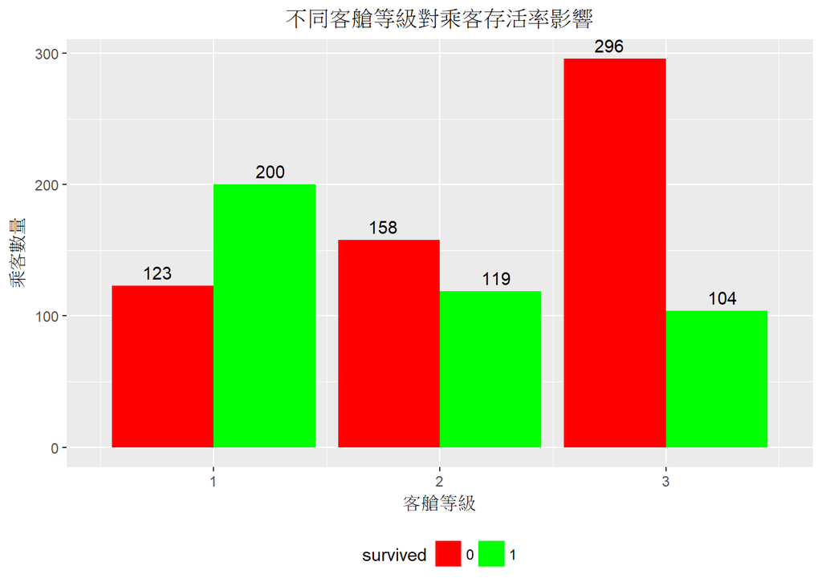

```r
data$survived <- factor(data$survived)
ggplot(data = data[1:nrow(train),], mapping = aes(x = pclass, y = ..count.., fill=survived)) +
  geom_bar(stat = "count", position='dodge') +
  xlab("客艙等級") +
  ylab("乘客數量") +
  ggtitle("不同客艙等級對乘客存活率影響") +
  scale_fill_manual(values=c("#FF0000", "#00FF00")) +
  geom_text(stat = "count", aes(label = ..count..), position=position_dodge(width=1), , vjust=-0.5) +
  theme(plot.title = element_text(hjust = 0.5), legend.position="bottom")
```

#### Pclass越高，存活率也越高

### 4. Name對存活率影響

#### 提取姓名中的title

```r
data$Title <- sapply(data$name, FUN=function(x) {strsplit(x, split='[,.]')[[1]][2]})
data$Title <- sub(" ","",data$Title)
table(data$Title)
```

```
##
##         Capt          Col          Don         Dona           Dr
##            1            4            1            1            8
##     Jonkheer         Lady        Major       Master         Miss
##            1            1            2           61          260
##         Mlle          Mme           Mr          Mrs           Ms
##            2            1          757          197            2
##          Rev          Sir the Countess
##            8            1            1
```

### 把數量較少的的Title歸到Others，從新分一下其他稱呼

```r
Others <- c('Capt','Col','Don','Dona','Jonkheer','Lady','Major','Sir','the Countess')
data$Title[data$Title=='Mlle'] <- 'Miss'
data$Title[data$Title=='Mme'] <- 'Mrs'
data$Title[data$Title=='Ms'] <- 'Miss'
data$Title[data$Title %in% Others] <- 'Others'
table(data$Title)
```

```
##
##     Dr Master   Miss     Mr    Mrs Others    Rev
##      8     61    264    757    198     13      8
```

### 用ggplot2繪製不同Title的乘客的存活數

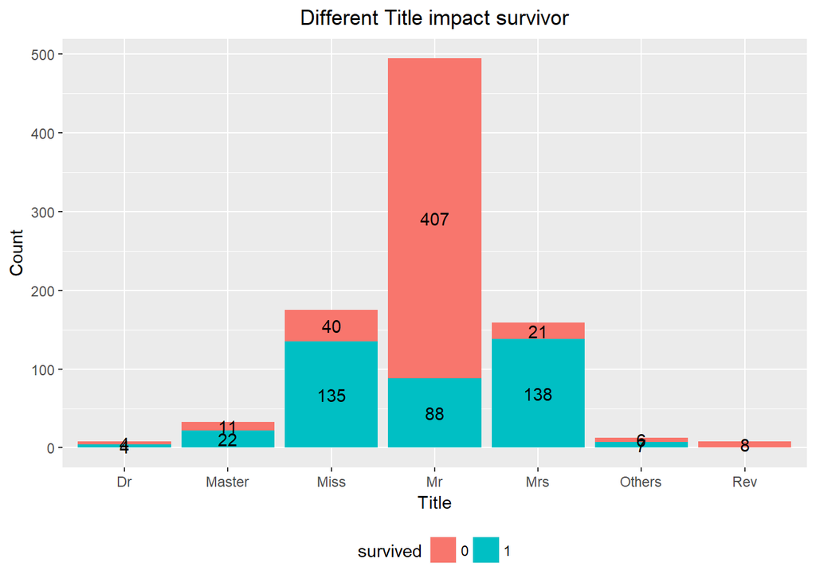

```r
ggplot(data = data[1:891,], mapping = aes(x = Title, y = ..count.., fill=survived)) +
  geom_bar(stat = "count", position='stack') +
  xlab('Title') +
  ylab('Count') +
  ggtitle('Different Title impact survivor') +
  scale_fill_discrete(name="survived", breaks=c(0, 1), labels=c("0", "1")) +
  geom_text(stat = "count", aes(label = ..count..), position=position_stack(vjust = 0.5)) +
  theme(plot.title = element_text(hjust = 0.5), legend.position="bottom")
```

#### Mr的存活率很低，Mrs和Miss比較高

### 5. sex對存活率影響

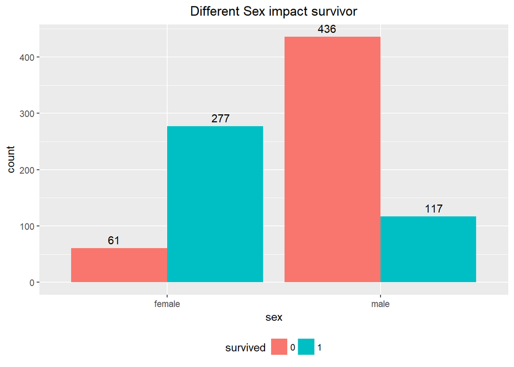

```r
data$sex <- as.factor(data$sex)
ggplot(data = data[1:891,], mapping = aes(x = sex, y = ..count.., fill=survived)) +
  geom_bar(stat = 'count', position='dodge') +
  xlab('sex') +
  ylab('count') +
  ggtitle('Different Sex impact survivor') +
  geom_text(stat = "count", aes(label = ..count..), position=position_dodge(width=1), , vjust=-0.5) +
  theme(plot.title = element_text(hjust = 0.5), legend.position="bottom")
```

#### 女性的存活率大於男性

### 6. sibsp對存活率影響 (sibsp是兄弟姊妹數與配偶數)

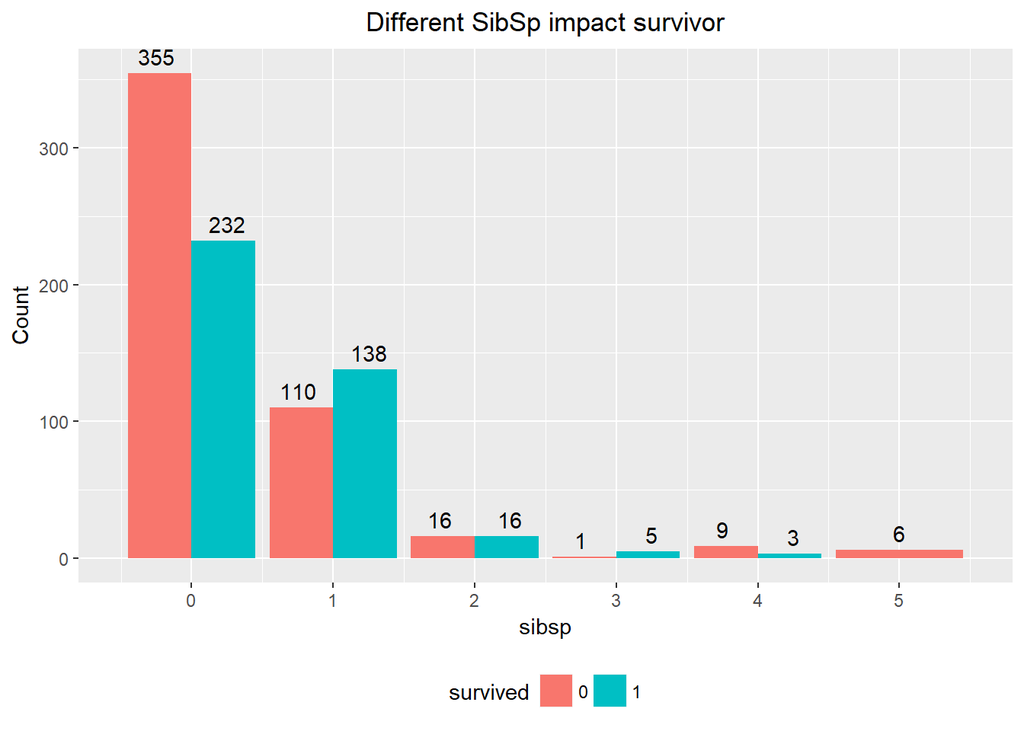

```r
ggplot(data = data[1:891,], mapping = aes(x = sibsp, y = ..count.., fill=survived)) +
  geom_bar(stat = 'count', position='dodge') +
  labs(title = "Different SibSp impact survivor", x = "sibsp", y = "Count", fill = "survived") +
  geom_text(stat = "count", aes(label = ..count..), position=position_dodge(width=1), , vjust=-0.5) +
  scale_x_continuous(breaks = c(0:8)) +
  theme(plot.title = element_text(hjust = 0.5), legend.position="bottom")
```

### 7. parch對存活率影響 (sibsp是父母數與子女數)

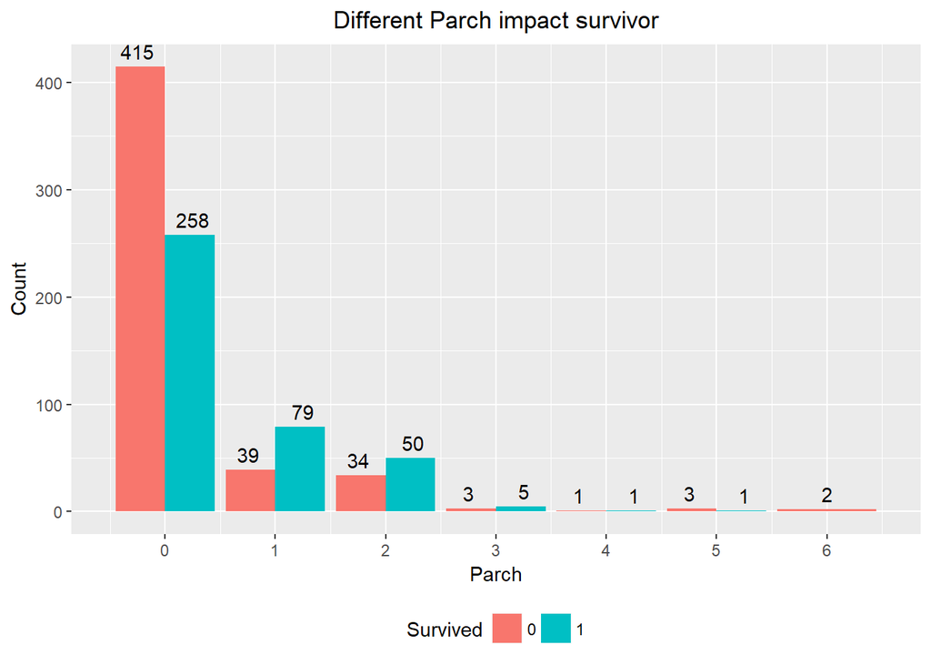

```r
ggplot(data = data[1:891,], mapping = aes(x = parch, y = ..count.., fill=survived)) +
  geom_bar(stat = 'count', position='dodge') +
  labs(title = "Different Parch impact survivor", x = "Parch", y = "Count", fill = "Survived") +
  geom_text(stat = "count", aes(label = ..count..), position=position_dodge(width=1), , vjust=-0.5) +
  scale_x_continuous(breaks = c(0:6)) +
  theme(plot.title = element_text(hjust = 0.5), legend.position="bottom")
```

#### SibSp和Parch在1-3时，存活率最高，而SibSp和Parch為0或大於4時，存活率下降

### 8. 利用SibSp和Parch增加新變量FamilySize對存活率影響

```r
data$FamilySize <- data$sibsp + data$parch + 1
data$FamilySize
```

[output not shown]

[output cut: 42 more lines]

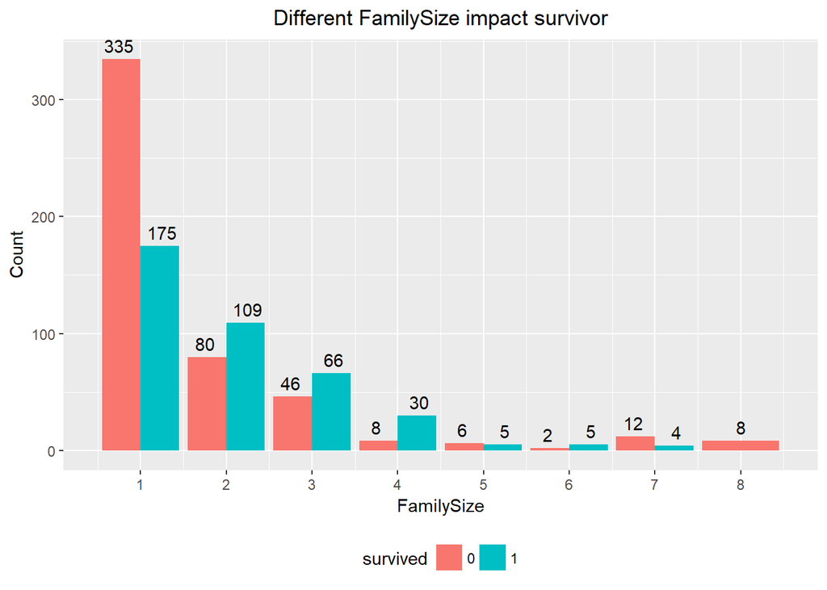

```r
ggplot(data = data[1:891,], mapping = aes(x = FamilySize, y = ..count.., fill=survived)) +
  geom_bar(stat = 'count', position='dodge') +
  xlab('FamilySize') +
  ylab('Count') +
  ggtitle('Different FamilySize impact survivor') +
  geom_text(stat = "count", aes(label = ..count..), position=position_dodge(width=1), , vjust=-0.5) +
  scale_x_continuous(breaks = c(0:11)) +
  theme(plot.title = element_text(hjust = 0.5), legend.position="bottom")
```

#### FamilySize在2-4時，存活率最高

### 8. age對存活率影響

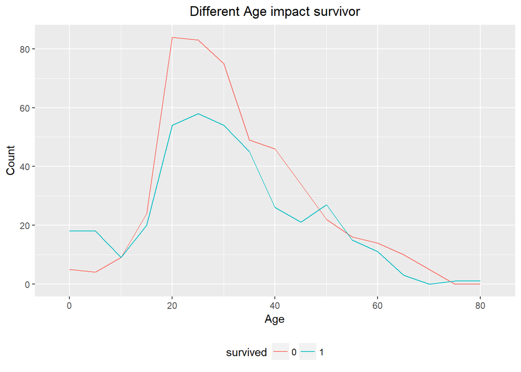

```r
ggplot(data[!is.na(data$survived),],aes(age,color=survived))+
  geom_line(aes(label=..count..), stat = 'bin', binwidth=5)  +
  labs(title = "Different Age impact survivor", x = "Age", y = "Count", fill = "Survived")+
  theme(plot.title = element_text(hjust = 0.5), legend.position="bottom")
```

```r
data$age_New[data$age < 18] <- 'child'
data$age_New[data$age >= 18] <- 'adult'
data$age_New
```

[output not shown]

[output cut: 149 more lines]

```r
table(data$age_New,data$survived)
```

```
##
##           0   1
##   adult 438 316
##   child  42  65
```

### 9. Age_New對存活率影響

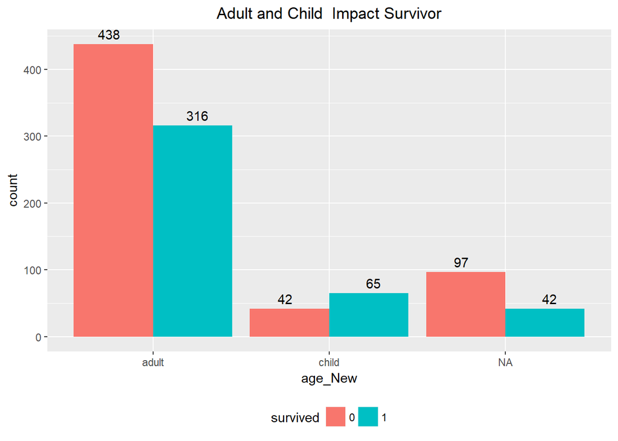

```r
ggplot(data[!is.na(data$survived),],aes(age_New,fill=survived))+
  geom_bar(stat = 'count',position = 'dodge')+
  ggtitle('Adult and Child  Impact Survivor')+
  geom_text(stat = "count", aes(label = ..count..), position=position_dodge(width=1), , vjust=-0.5) +
  theme(plot.title = element_text(hjust = 0.5), legend.position="bottom")
```

### 10. fare對存活率影響

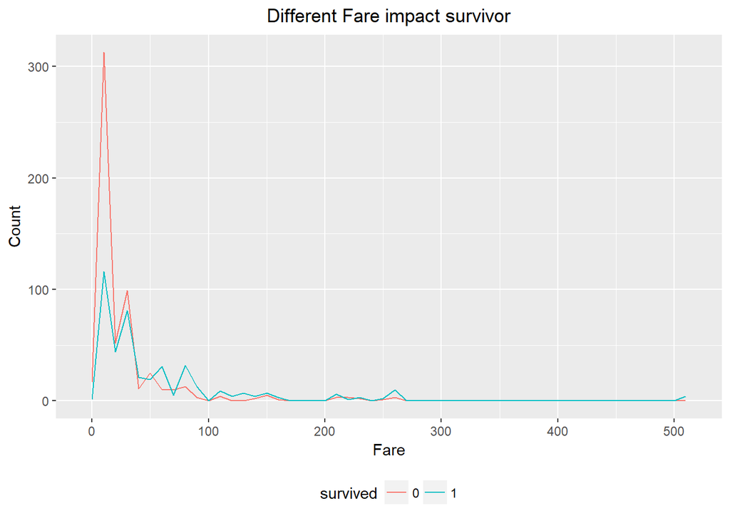

```r
ggplot(data = data[!is.na(data$survived) ,], aes(x = fare, color=survived)) +
  geom_line(aes(label=..count..), stat = 'bin', binwidth=10)  +
  labs(title = "Different Fare impact survivor", x = "Fare", y = "Count", fill = "Survived")+
  theme(plot.title = element_text(hjust = 0.5), legend.position="bottom")
```

#### fare越高，存活率越高

### 11. Embarked對存活率影響

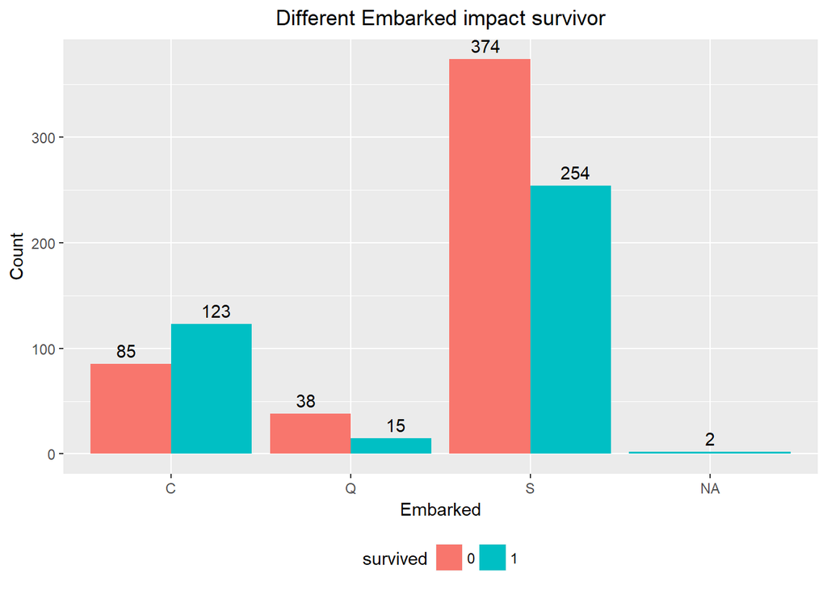

```r
ggplot(data[1:891, ], mapping = aes(x = embarked, y = ..count.., fill = survived)) +
  geom_bar(stat = 'count', position='dodge') +
  xlab('Embarked') +
  ylab('Count') +
  ggtitle('Different Embarked impact survivor') +
  geom_text(stat = "count", aes(label = ..count..), position=position_dodge(width=1), , vjust=-0.5) +
  theme(plot.title = element_text(hjust = 0.5), legend.position="bottom")
```

## 第二階段－補充缺失值

### 1. 查看缺失值

```r
sapply(data, function(x) sum(is.na(x)))
```

```
##     pclass   survived       name        sex        age      sibsp
##          0        309          0          0        263          0
##      parch     ticket       fare      cabin   embarked       boat
##          0          0          1       1014          2        823
##       body  home.dest      Title FamilySize    age_New
##       1188        564          0          0        263
```

### 2. 補充Embarked缺失值

```r
embarked.na <- data$embarked
data_169 <- data[169,]
data_285 <- data[285,]
data_169
```

```
##     pclass survived                name    sex age sibsp parch ticket fare
## 169      1        1 Icard, Miss. Amelie female  38     0     0 113572   80
##     cabin embarked boat body home.dest Title FamilySize age_New
## 169   B28     <NA>    6   NA      <NA>  Miss          1   adult
```

```r
data_285
```

```
##     pclass survived                                      name    sex age
## 285      1        1 Stone, Mrs. George Nelson (Martha Evelyn) female  62
##     sibsp parch ticket fare cabin embarked boat body      home.dest Title
## 285     0     0 113572   80   B28     <NA>    6   NA Cincinatti, OH   Mrs
##     FamilySize age_New
## 285          1   adult
```

#### 169和285乘客的Fare都是80， Pclass都是1，假設票價、艙等相同的乘客都在同一個地方上船

#### 把Embarked的缺失值補為C

```r
data$embarked[c(169, 285)] <- "C"
```

### 3. 補充fare缺失值

#### 查看缺失值位置和相關信息

```r
fare.na <- is.na(data$fare)
which(fare.na %in% TRUE)
```

```
## [1] 1226
```

```r
data_1226 <- data[1226, ]
data_1226
```

```
##      pclass survived               name  sex  age sibsp parch ticket fare
## 1226      3     <NA> Storey, Mr. Thomas male 60.5     0     0   3701   NA
##      cabin embarked boat body home.dest Title FamilySize age_New
## 1226  <NA>        S <NA>  261      <NA>    Mr          1   adult
```

#### 用中位數補上缺失值

```r
data$fare[1226] <- 8.05
sapply(data,function(x) sum(is.na(x)))
```

```
##     pclass   survived       name        sex        age      sibsp
##          0        309          0          0        263          0
##      parch     ticket       fare      cabin   embarked       boat
##          0          0          0       1014          0        823
##       body  home.dest      Title FamilySize    age_New
##       1188        564          0          0        263
```

### 4. 補充age缺失值

#### Age缺失的數據為263個，使用多重插補法用MICE預測填補Age的缺失數據

```r
data[is.na(data$age), ]
```

[output not shown]

[output cut: 1041 more lines]

```r
set.seed(129)
ss <- c('name','ticket','cabin','FamilySize','Survived')
mice_age <- mice(data[,!names(data) %in% ss],method = 'rf')
mice_output <- complete(mice_age)
data$age <- mice_output$age
sapply(data,function(x) sum(is.na(x)))
```

```
##     pclass   survived       name        sex        age      sibsp
##          0        309          0          0          0          0
##      parch     ticket       fare      cabin   embarked       boat
##          0          0          0       1014          0        823
##       body  home.dest      Title FamilySize    age_New
##       1188        564          0          0        263
```

#### 補上age_new

```r
data$age_New[data$age < 18] <- 'child'
data$age_New[data$age >= 18] <- 'adult'
data$age_New
```

[output not shown]

[output cut: 149 more lines]

```r
table(data$age_New,data$survived)
```

```
##
##           0   1
##   adult 520 355
##   child  57  68
```

```r
sapply(data,function(x) sum(is.na(x)))
```

```
##     pclass   survived       name        sex        age      sibsp
##          0        309          0          0          0          0
##      parch     ticket       fare      cabin   embarked       boat
##          0          0          0       1014          0        823
##       body  home.dest      Title FamilySize    age_New
##       1188        564          0          0          0
```

#### 會用到的缺失值都補完了

## 第三階段－建立模型、預測

### 1. 建立模型

```r
data$pclass <- factor(data$pclass)
data$Title <- factor(data$Title)
data$sex <- factor(data$sex)
data$age_New <- factor(data$age_New)
data$FamilySize <- factor(data$FamilySize)
data$fare <- factor(data$fare)
data$embarked <- factor(data$embarked)
train <- data[1:1000,]
test <- data[1001:1309,]
set.seed(102)
model <- cforest(factor(survived) ~ pclass + Title + sex + age_New + FamilySize + fare + embarked, data = train)
```

### 2. 預測結果

```r
predict1 <- predict(model, test,  OOB=TRUE, type = "response")
```

#### 試算準確率

```r
predict2 <- predict(model, train,  OOB=TRUE, type = "response")
success <- 0
for(i in c(1:1000)){
  if(predict2[i] == data$survived[i]){
    success <- success + 1
  }
}
print(success / 1000)
```

```
## [1] 0.825
```

### 3. 輸出結果

```r
output <- data.frame(survived = predict1)
write.csv(output, file = "predict.csv", row.names = FALSE)
```

## 結論

#### 這次的部分真的有點小難，上禮拜花了五六兩天都在研究，還是有很多問題，做的也沒有很好，一開始也不知道要怎麼分析這些變數與存活的關係，只知道看基本原來就有的變量，後來上網查了很多資料、看了網路上其他人寫的CODE，才知道可以加上TITLE、FamilySize等等，也了解前面資料整理的重要性，模型的準確率攸關前面資料的整理，模型只是把整理過後的資料丟進去而已，這次自己也是很間單的整理而已，還有很多變量可以加上去

### cforest跑得有點久，害我一度以為我的電腦當機了，很可惜這禮拜卡到期中考，沒有什麼時間深入研究，這個部分還有很多不懂得，完成這次作業讓我對R的建模有初步的了解，再結合前期一些簡單的資料處理，應該算是對資料分析的整個流程多了一點認識，以後還要繼續加強學習